# Lab 9

Khudoyarova Anastasia

12/20/2020

# Загружаем данные

```r
rawdata <- read.csv(file = "survey.csv")
head(rawdata)
```

|  | MYDEPV | Price | Income | Age |
| --- | --- | --- | --- | --- |
| 1 | 1 | 10 | 33 | 37 |
| 2 | 0 | 20 | 21 | 55 |
| 3 | 1 | 30 | 59 | 55 |
| 4 | 1 | 20 | 76 | 44 |
| 5 | 0 | 30 | 24 | 37 |
| 6 | 0 | 20 | 22 | 32 |

И делим на тестовые и тренировочные данные

```r
train_df <- as.data.frame(rawdata[1:600,])
test_df <- as.data.frame(rawdata[601:750,])
```

# Создание дерева решений

Тут мы используем пакет rpart

```r
tree <- rpart(as.factor(MYDEPV) ~ Price + Income + Age,
              method="class",
              data=train_df,
              parms=list(split='information'))
```

и выводим информацию о complexity parameter

```r
printcp(tree)
```

```
##
## Classification tree:
## rpart(formula = as.factor(MYDEPV) ~ Price + Income + Age, data = train_df,
##     method = "class", parms = list(split = "information"))
##
## Variables actually used in tree construction:
## [1] Age    Income Price
##
## Root node error: 260/600 = 0.43333
##
## n= 600
##
##         CP nsplit rel error  xerror     xstd
## 1 0.692308      0   1.00000 1.00000 0.046685
## 2 0.025000      1   0.30769 0.31154 0.032194
## 3 0.011538      3   0.25769 0.26538 0.030055
## 4 0.010256      5   0.23462 0.26538 0.030055
## 5 0.010000     11   0.17308 0.25769 0.029672
```

Используем функцию plot в rpart

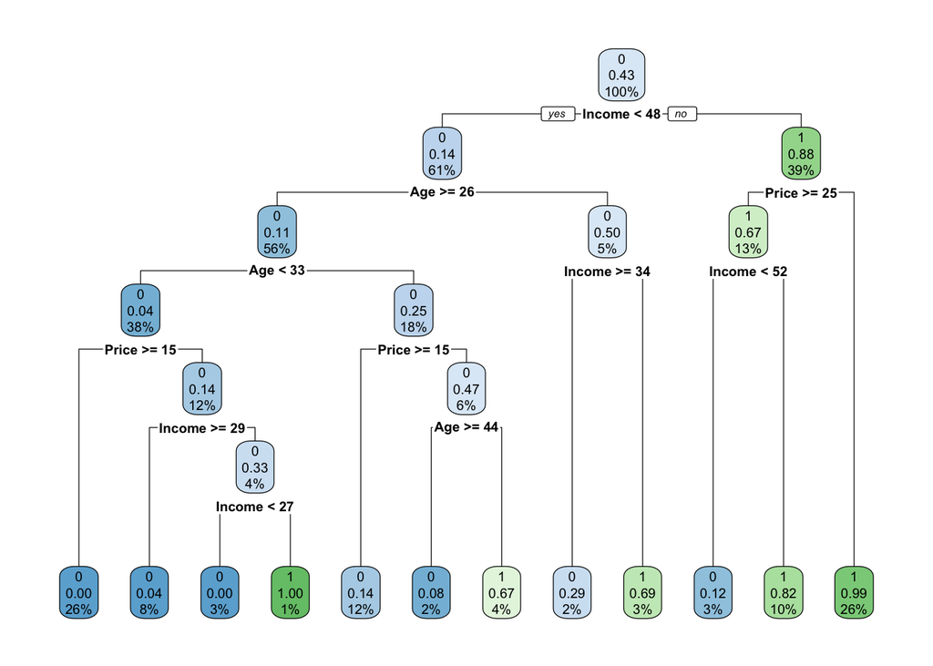

```r
rpart.plot(tree)
```

# Построение Confusion matrix

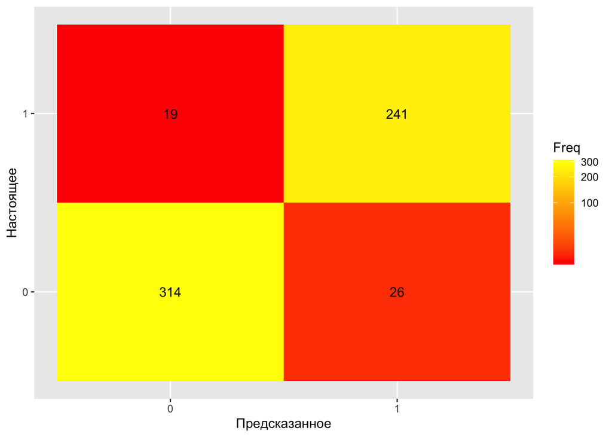

```r
prediction = predict(tree, train_df, type="class")
confmatrix <- as.data.frame(table(prediction, train_df$MYDEPV))
ggplot(data = confmatrix, mapping = aes(x = prediction, y = Var2)) +
  geom_tile(aes(fill = Freq)) + geom_text(aes(label = Freq)) +
  scale_fill_gradient(low = "red", high = "yellow",
                      trans = "pseudo_log") +
  labs(x = "Предсказанное", y = "Настоящее")
```

# Misclassification rate

Посчет ошибок по принципу - посчитали, что верно, вычли это из 1 => получаем ошибки

```r
pred <- table(train_df$MYDEPV, prediction)
misfor.all <- 1 - (sum(diag(pred)) / sum(pred))
misfor.zero <- 1 - (pred[1,1] / sum(pred[1,]))
misfor.one <- 1 - (pred[2,2] / sum(pred[2,]))

cat("for overall ", misfor.all, "\n")
```

```
## for overall  0.075
```

```r
cat("for zero ", misfor.zero, "\n")
```

```
## for zero  0.07647059
```

```r
cat("for one ", misfor.one, "\n")
```

```
## for one  0.07307692
```

# Построим кривую ROC

Для этого используем удобный пакет pROC. Передаем ему наши данные и получаем - AUC = 0.925

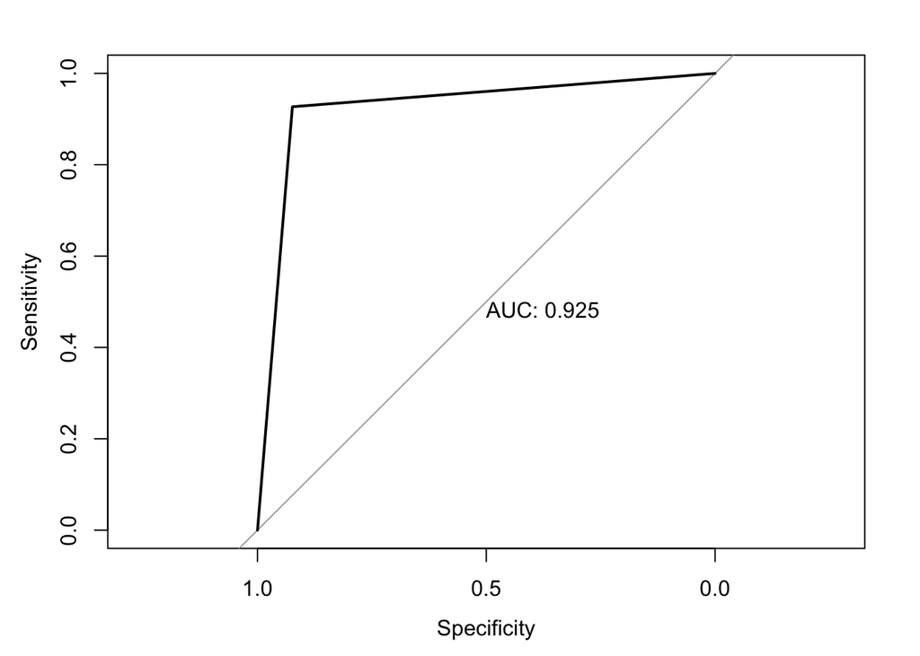

```r
sroc <- roc(train_df$MYDEPV ~ as.numeric(prediction), plot=TRUE, print.auc=TRUE)
```

# Misclassification rate для тестовой выборки

Считаем аналогично коду выше, но для этого получаем prediction_test на основе дерева и тестовых данных

```r
prediction_test = predict(tree, test_df, type="class")
pred2 <- table(test_df$MYDEPV, prediction_test)
misfor.all2 <- 1 - (sum(diag(pred2)) / sum(pred2))
misfor.zero2 <- 1 - (pred2[1,1] / sum(pred2[1,]))
misfor.one2 <- 1 - (pred2[2,2] / sum(pred2[2,]))

cat("for overall ", misfor.all2, "\n")
```

```
## for overall  0.1066667
```

```r
cat("for zero ", misfor.zero2, "\n")
```

```
## for zero  0.1162791
```

```r
cat("for one ", misfor.one2, "\n")
```

```
## for one  0.09375
```

# Разделяющий параметр Gini

Используем для построения дерева решений разделяющий параметр Gini. Многие статьи пишут, что для большинства датасетов этот индекс (index) ведет себя также как и information - проверим

```r
tree2 <- rpart(as.factor(MYDEPV) ~ Price + Income + Age,
               method="class",
               data=train_df,
               parms=list(split='gini'))
```

Выедем complexity parameter

```r
printcp(tree2)
```

```
##
## Classification tree:
## rpart(formula = as.factor(MYDEPV) ~ Price + Income + Age, data = train_df,
##     method = "class", parms = list(split = "gini"))
##
## Variables actually used in tree construction:
## [1] Age    Income Price
##
## Root node error: 260/600 = 0.43333
##
## n= 600
##
##         CP nsplit rel error  xerror     xstd
## 1 0.692308      0   1.00000 1.00000 0.046685
## 2 0.025000      1   0.30769 0.31154 0.032194
## 3 0.011538      3   0.25769 0.25769 0.029672
## 4 0.010256      5   0.23462 0.28846 0.031157
## 5 0.010000     11   0.17308 0.27308 0.030430
```

И построим дерево

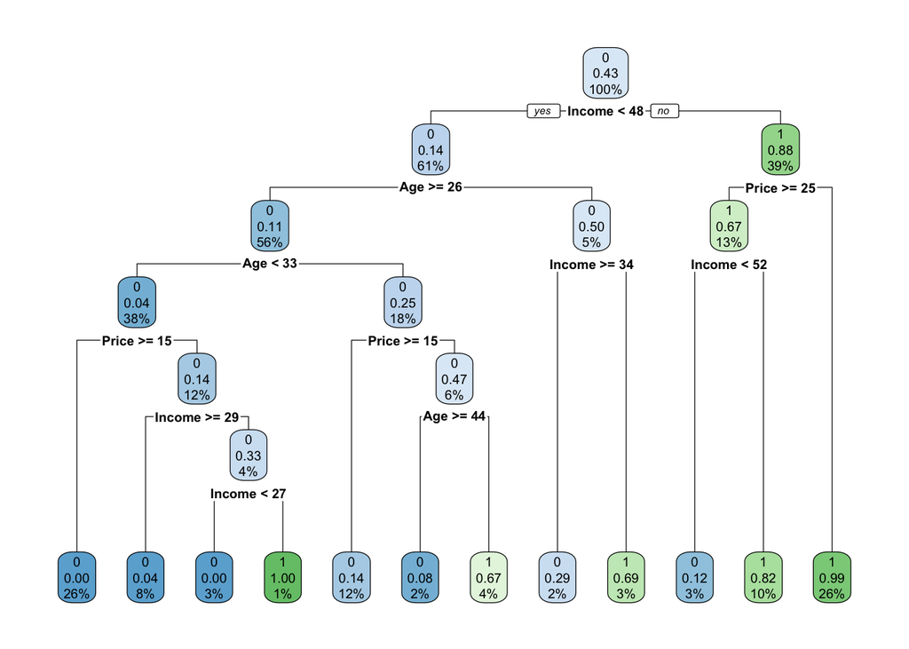

```r
rpart.plot(tree2)
```

Дейстриветльно - изображения один в один, даже параметры деления

# Обрезка дерева

Выберем параметр cp, рекомендуют выбирать параметр для которого получается наименьшая ошибка - xerror: тогда возьмем: `cp = 0.011538`

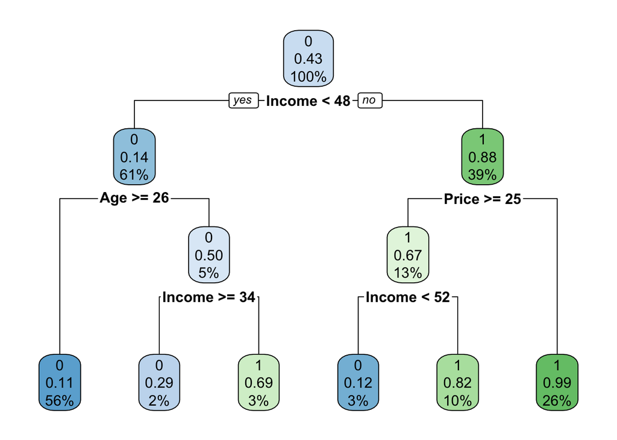

```r
cutted_tree = prune(tree2, cp = 0.011538)
rpart.plot(cutted_tree)
```

# Финал

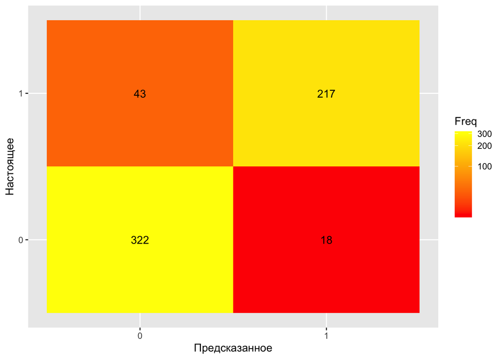

```r
prediction_cut = predict(cutted_tree, train_df, type="class")
confmatrix2 <- as.data.frame(table(prediction_cut, train_df$MYDEPV))
ggplot(data = confmatrix2, mapping = aes(x = prediction_cut, y = Var2)) +
  geom_tile(aes(fill = Freq)) + geom_text(aes(label = Freq)) +
  scale_fill_gradient(low = "red", high = "yellow",
                      trans = "pseudo_log") +
  labs(x = "Предсказанное", y = "Настоящее")
```

```r
prediction_cut_t = predict(tree2, train_df, type="class")
pred3 <- table(train_df$MYDEPV, prediction_cut_t)
misfor.all3 <- 1 - (sum(diag(pred3)) / sum(pred3))
misfor.zero3 <- 1 - (pred3[1,1] / sum(pred3[1,]))
misfor.one3 <- 1 - (pred3[2,2] / sum(pred3[2,]))

cat("for overall ", misfor.all3, "\n")
```

```
## for overall  0.075
```

```r
cat("for zero ", misfor.zero3, "\n")
```

```
## for zero  0.07647059
```

```r
cat("for one ", misfor.one3, "\n")
```

```
## for one  0.07307692
```

# Заключение

Данный метод прост и красив, он понятен людям далеким от анализа данных и во многом он стабильнее и надежнее остальных методов Data Mining. Но и он может давать ошибки